# Unsupervised Learning

This R markdown tries to add some value to our initial dataset by using unsupervised learning. We will try to clusterize our dataset using different combination of variables in the hope that the clusters might provide valuable insights to a management team.

## Craigslist Vehicles

First, we are going to import the cleaned dataset.

```r
data <- read.csv("data/data_abe.csv")
data$X <- NULL # Remove the index from the csv
data <- na.omit(data) # Remove potential NA
dim(data)
```

```
## [1] 414822     17
```

```r
colnames(data)
```

```
##  [1] "city"         "price"        "year"         "manufacturer" "make"
##  [6] "condition"    "cylinders"    "fuel"         "odometer"     "title_status"
## [11] "transmission" "drive"        "size"         "type"         "paint_color"
## [16] "lat"          "long"
```

## 1. Geographical segmentation

We want to divide our American market into several regions. Nevertheless, we don’t know how to properly define the regions, and how many regions we should have.

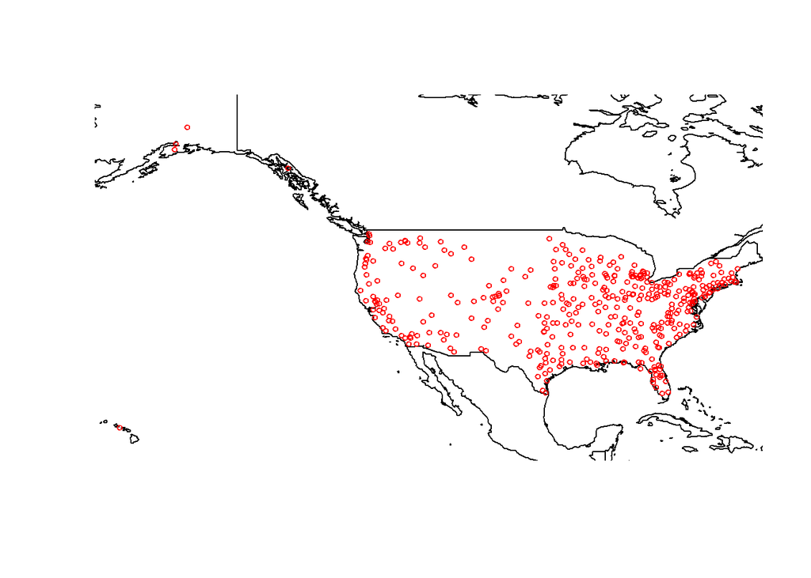

```r
newmap <- getMap(resolution = "low")
xlim= c(min(data$long, na.rm=T), max(data$long, na.rm=T)) #long
ylim= c(min(data$lat, na.rm=T), max(data$lat, na.rm=T)) #lat
plot(newmap, xlim = xlim, ylim = ylim, asp = 1)
points(data$long, data$lat, col = "red", cex = .6)
```

In order to solve this problem, we are going to use clustering on the latitude and longitude of our dataset. Let’s find out how many clusters we should create.

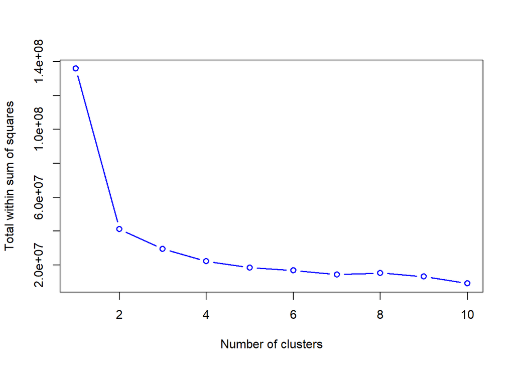

```r
# We need to normalize our values
data$scaled_lat <- scale(data$lat)
data$scaled_long <- scale(data$long)
# First, let's find the optimal number of clusters
total_within_ss <- rep(0, times=10)
for(i in 1:10){
  km <- kmeans(data[, c("lat","long")], i)
  total_within_ss[i] <- km$tot.withinss
}
plot(total_within_ss, type="b",xlab="Number of clusters",ylab="Total within sum of squares", col="blue", lwd=1.5)
```

As we can see, applying the elbow rule, 2 seems to be the best number of clusters for our problem. We are now going to apply the kmeans algorithm to our dataset and plot the generated clusters.

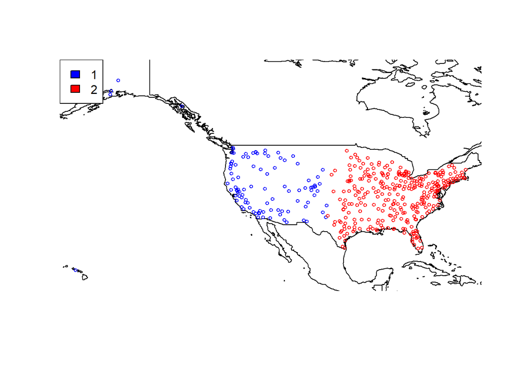

```r
km <- kmeans(data[, c("lat","long")], 2, nstart=5)
data$geographical_cluster <- km$cluster
newmap <- getMap(resolution = "low")
plot(newmap, xlim = xlim, ylim = ylim, asp = 1)
points(data[data$geographical_cluster == 1,]$long, data[data$geographical_cluster == 1,]$lat, col="blue", cex=.6)
points(data[data$geographical_cluster == 2,]$long, data[data$geographical_cluster == 2,]$lat, col="red", cex=.6)
legend("topleft", c("1","2"), fill=c("blue","red"))
```

Our recommandation for market geographical segmentation is to separate the country in two segments: - Eastern - Western

The boundaries are defined by the map printed earlier.

Nevertheless, if for business purposes, it is necessary to split the market into more than two sub-markets, this K-means algorithm is able to provide us with the most homogeneous sub-markets.

Finally, we will use the explained inertia metrics to evaluate our Kmeans algorithm.

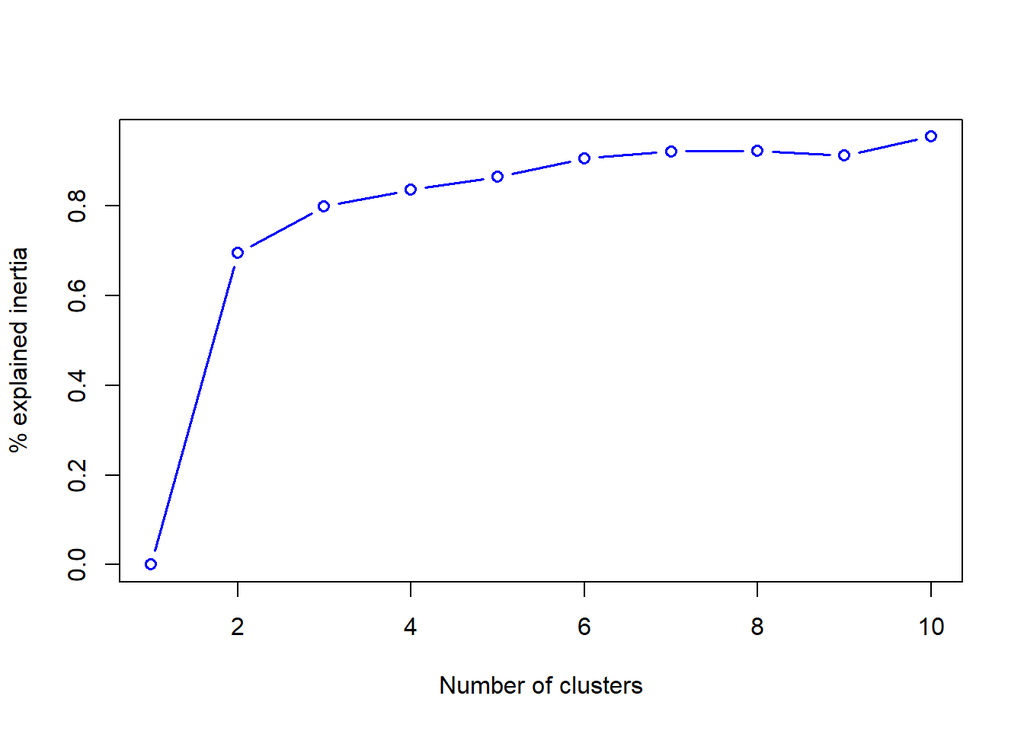

```r
explaned_inertia <- rep(0,times=10)
for (k in 2:10){
  clus <- kmeans(data[, c("lat","long")],centers=k,nstart=5)
  explaned_inertia[k] <- clus$betweenss/clus$totss
}

plot(1:10,explaned_inertia,type="b",xlab="Number of clusters",ylab="% explained inertia", col="blue", lwd=1.5)
```

## 2. Vehicles segmentation

We are now going to try and segment the vehicles found on Craigslist. In order to do so, we are first going to perform a MCA on the variables (since they are categorical variables), and then to perform clustering.

### 2.1. Multiple Component Analysis

The goal of the MCA here is to convert our categorical data to numerical. Thus, we are going to keep every dimensions of the MCA, since we do not want to reduce the dimensionality of our dataset and, thus, to loose information.

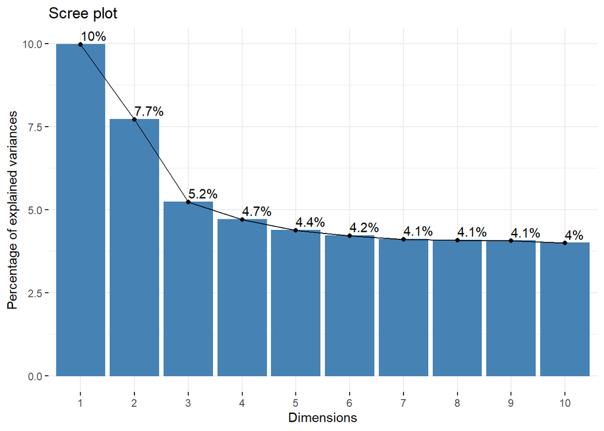

```r
# Performing a MCA keeping all the dimensions.
data.mca <- MCA(data[,c("manufacturer", "condition", "fuel", "transmission", "drive", "size", "type", "paint_color")], ncp=Inf, graph=FALSE, level.ventil=0.05)

# Visualizing the dimensions contributions
fviz_screeplot (data.mca, addlabels = TRUE)
```

We can better understand our MCA axes with the following graph.

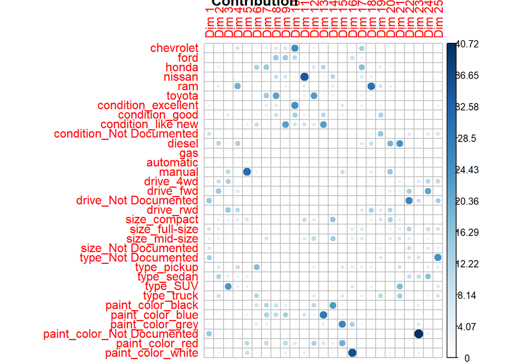

```r
# Getting the MCA variables
var <- get_mca_var(data.mca)
# Plotting the correlations between variables and MCA axes
corrplot(var$contrib, is.corr=FALSE,main="Contribution")
```

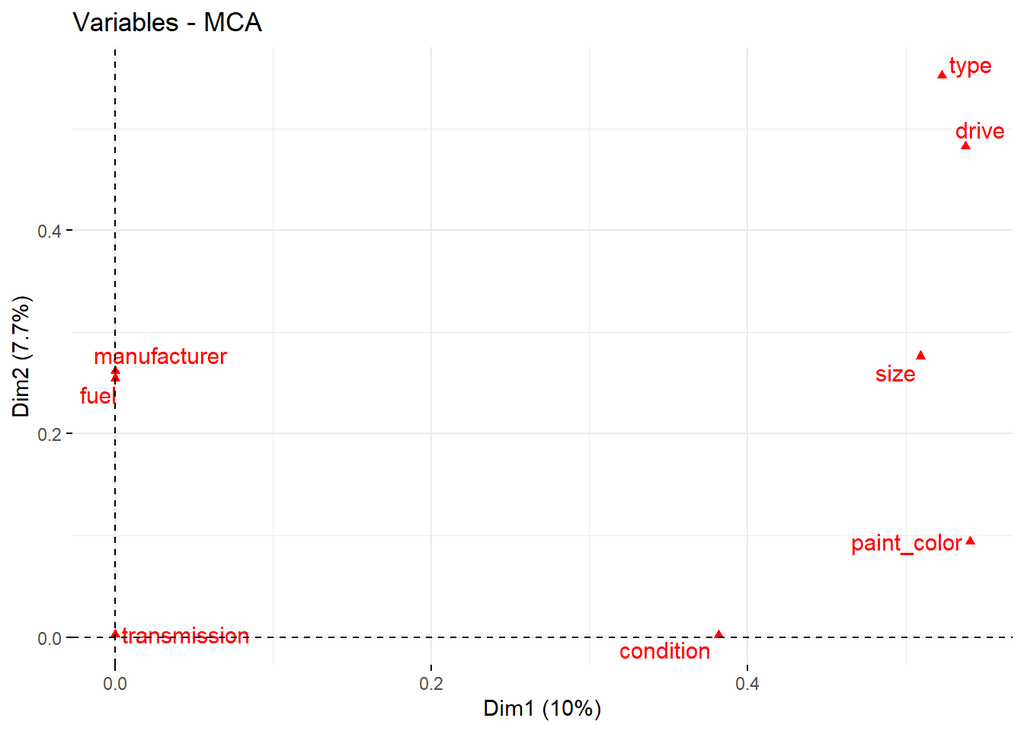

```r
fviz_mca_var (data.mca, choice = "mca.cor", repel=TRUE)
```

### 2.2. K-Means Clustering

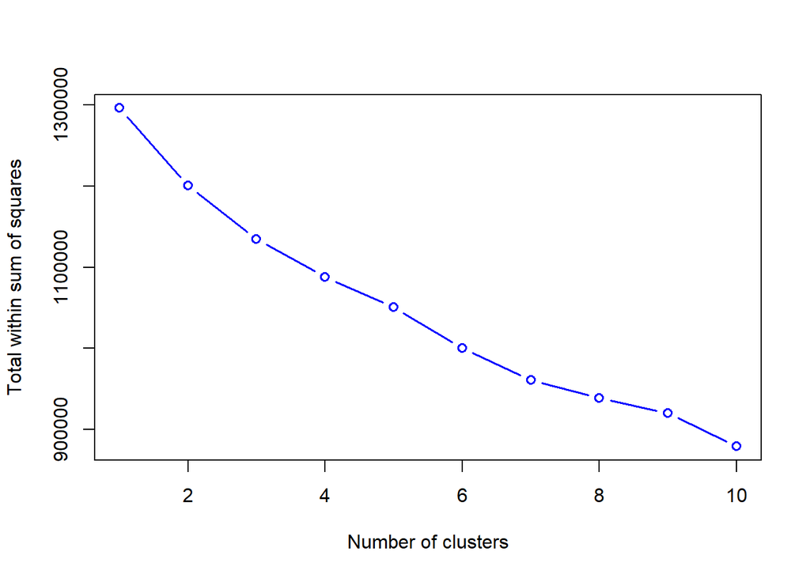

```r
# Let's find the optimal number of clusters
total_within_ss <- rep(0, times=10)
for(i in 1:10){
  km <- kmeans(data.mca$ind$coord, i, nstart=5)
  total_within_ss[i] <- km$tot.withinss
}
plot(total_within_ss, type="b",xlab="Number of clusters",ylab="Total within sum of squares", col="blue", lwd=1.5)
```

Let’s actually apply the Kmeans clustering.

```r
km <- kmeans(data.mca$ind$coord, 8, nstart=5)
data$vehicle_cluster <- km$cluster
```

Finally, let’s visualize our clusters on the two first principal components of the MCA.

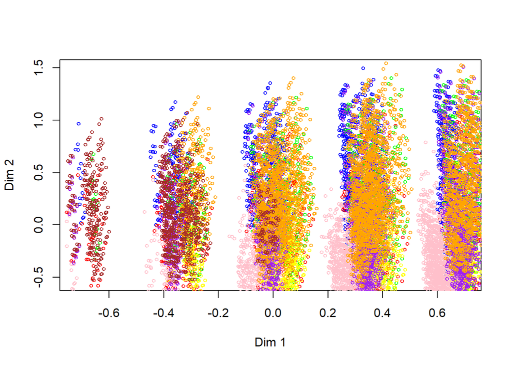

```r
# Plot the first two coordinates, cluster by cluster
plot(data.mca$ind$coord[data$vehicle_cluster==1, 1:2], col="blue", xlab="Dim 1",ylab="Dim 2", cex=.6)
points(data.mca$ind$coord[data$vehicle_cluster==2, 1:2], col="red", cex=.6)
points(data.mca$ind$coord[data$vehicle_cluster==3, 1:2], col="green", cex=.6)
points(data.mca$ind$coord[data$vehicle_cluster==4, 1:2], col="yellow", cex=.6)
points(data.mca$ind$coord[data$vehicle_cluster==5, 1:2], col="pink", cex=.6)
points(data.mca$ind$coord[data$vehicle_cluster==6, 1:2], col="purple", cex=.6)
points(data.mca$ind$coord[data$vehicle_cluster==7, 1:2], col="orange", cex=.6)
points(data.mca$ind$coord[data$vehicle_cluster==8, 1:2], col="brown", cex=.6)
```

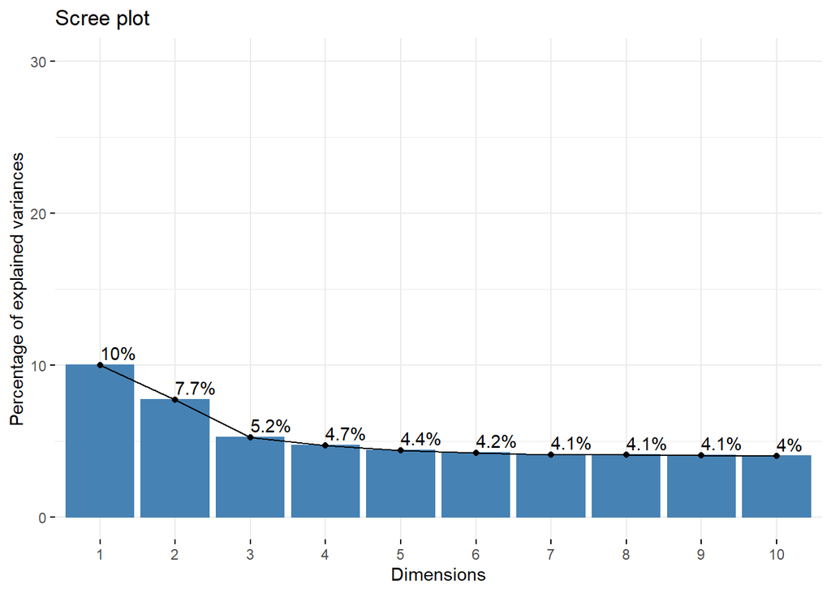

```r
fviz_eig(data.mca, addlabels = TRUE, ylim = c(0, 30))
```

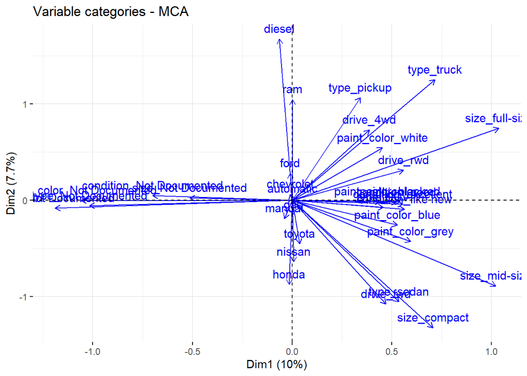

```r
fviz_pca_var(data.mca, col.var ="blue")
```

## 3. Offers segmentation

We are now going to segment the offers placed on Craigslist based on 3 numerical variables: the prices, the vehicle’s year, and the odometer. Our goal is to provide management with information about the various, interpretable, segments of second hand vehicles sold on Craigslist.

```r
# Scaling our values
data$scaled_price = scale(data$price)
data$scaled_year = scale(data$year)
data$scaled_odometer = scale(data$odometer)

# Let's find the optimal number of clusters
total_within_ss <- rep(0, times=10)
for(i in 1:10){
  km <- kmeans(data[, c("scaled_price", "scaled_year", "scaled_odometer")], i)
  total_within_ss[i] <- km$tot.withinss
}
```

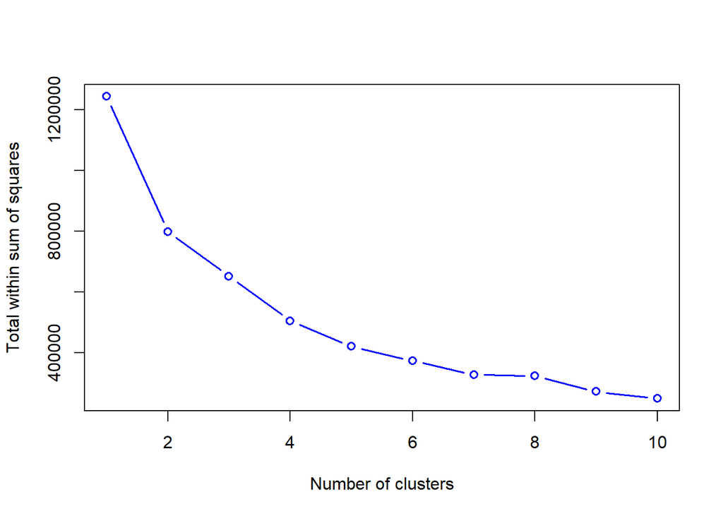

```r
plot(total_within_ss, type="b",xlab="Number of clusters",ylab="Total within sum of squares", col="blue", lwd=1.5)
```

The elbow rule is not perfect for our fit, but we have arbitrarily defined 4 as the optimal number of clusters, after trying other possibilities. Let’s actually apply the clustering.

```r
km <- kmeans(data[, c("scaled_price", "scaled_year", "scaled_odometer")], 4)
data$offer_cluster <- km$cluster
```

Finally, we can visualize and interpret our clusters.

```r
points3D(data$year, data$odometer, data$price,
         colvar=data$offer_cluster,
         xlab="Year", ylab="Odometer", zlab="Price"
)
```

[figure not shown]